Skip to main content

# The neighbourhood of my five flux towers

Author

Matti Allgaier

Published

November 23, 2026

**Source code:** https://github.com/Algaistrahlt/datascience_env_monit (report: `reports/w05_ma447_neighbours.qmd`)

## 1. Data and provenance

Five external datasets were added to the FLUXNET data from Block 4. All were downloaded with the Block 5 scripts and are stored in `data/external/`.

```r
tibble::tribble(
  ~Dataset,          ~Source,                                ~Resolution,              ~Period,                  ~`Accessed`,   ~Citation,
  "FLUXNET (ONEFlux v1.3)", "FLUXNET Shuttle (AmeriFlux, ICOS)", "tower, 30 min",        "tower years (1999–2025)", "2026-11-13", "Site citations (see Block 4); Pastorello et al. (2020)",
  "SoilGrids 2.0",   "ISRIC, rest.isric.org",                "250 m, 6 depths",        "static",                 "2026-11-20", "Poggio et al. (2021) SOIL 7, 217–240",
  "PlantTraits",     "planttraits.earth / Zenodo",           "1 km",                   "static",                 "2026-11-20", "Lusk et al. (2026) Nat. Commun. 17, 1203; doi.org/10.5281/zenodo.14646322",
  "WorldClim 2.1",   "worldclim.org (via geodata)",          "5′ (~9 km)",             "1970–2000 normals",      "2026-11-20", "Fick & Hijmans (2017) Int. J. Climatol. 37, 4302–4315",
  "iNaturalist",     "api.inaturalist.org/v1",               "points, 5 km radius",    "all records to date",    "2026-11-20", "iNaturalist contributors (2026), accessed 2026-11-20",
  "MODIS MOD13Q1",   "ORNL DAAC subset service",             "250 m, 16 days (9 × 9 px)", "last 3 tower years",   "2026-11-23", "Didan (2021) doi.org/10.5067/MODIS/MOD13Q1.061; ORNL DAAC doi.org/10.3334/ORNLDAAC/1557"
) |>
  knitr::kable()
```

| Dataset | Source | Resolution | Period | Accessed | Citation |
| --- | --- | --- | --- | --- | --- |
| FLUXNET (ONEFlux v1.3) | FLUXNET Shuttle (AmeriFlux, ICOS) | tower, 30 min | tower years (1999–2025) | 2026-11-13 | Site citations (see Block 4); Pastorello et al. (2020) |
| SoilGrids 2.0 | ISRIC, rest.isric.org | 250 m, 6 depths | static | 2026-11-20 | Poggio et al. (2021) SOIL 7, 217–240 |
| PlantTraits | planttraits.earth / Zenodo | 1 km | static | 2026-11-20 | Lusk et al. (2026) Nat. Commun. 17, 1203; doi.org/10.5281/zenodo.14646322 |
| WorldClim 2.1 | worldclim.org (via geodata) | 5′ (~9 km) | 1970–2000 normals | 2026-11-20 | Fick & Hijmans (2017) Int. J. Climatol. 37, 4302–4315 |
| iNaturalist | api.inaturalist.org/v1 | points, 5 km radius | all records to date | 2026-11-20 | iNaturalist contributors (2026), accessed 2026-11-20 |
| MODIS MOD13Q1 | ORNL DAAC subset service | 250 m, 16 days (9 × 9 px) | last 3 tower years | 2026-11-23 | Didan (2021) doi.org/10.5067/MODIS/MOD13Q1.061; ORNL DAAC doi.org/10.3334/ORNLDAAC/1557 |

## 2. Site portrait

All values come from `data/processed/site_static.csv` (built by `09_merge.R`). Soil values are thickness-weighted means over 0–30 cm.

```r
site_static <- read_csv("data/processed/site_static.csv", show_col_types = FALSE)
```

### Climate (WorldClim 2.1, 1970–2000)

```r
site_static |>
      mutate(lat = paste0(abs(round(lat, 2)), "° ", if_else(lat < 0, "S", "N")),
         lon = paste0(abs(round(lon, 2)), "° ", if_else(lon < 0, "W", "E"))) |>
  select(Site = site_id, IGBP = igbp,
        Lat = lat, Lon = lon,
         `BIO1 mean temp. (°C)` = BIO1,
         `BIO4 temp. seasonality (°C × 100)` = BIO4,
         `BIO12 annual precip. (mm)` = BIO12,
         `BIO15 precip. seasonality (%)` = BIO15) |>
  knitr::kable(digits = 1)
```

| Site | IGBP | Lat | Lon | BIO1 mean temp. (°C) | BIO4 temp. seasonality (°C × 100) | BIO12 annual precip. (mm) | BIO15 precip. seasonality (%) |
| --- | --- | --- | --- | --- | --- | --- | --- |
| BR-Ma2 | EBF | 2.61° S | 60.21° W | 26.4 | 44.7 | 2348 | 42.5 |
| JP-Fhk | DNF | 35.44° N | 138.76° E | 10.8 | 796.9 | 1617 | 54.5 |
| IT-Tor | GRA | 45.84° N | 7.58° E | -0.7 | 580.0 | 1116 | 12.9 |
| US-UiB | CRO | 40.06° N | 88.2° W | 11.0 | 1024.2 | 1016 | 26.0 |
| CN-Zha | WET | 38.98° N | 100.45° E | 7.1 | 1087.7 | 192 | 104.1 |

The WorldClim annual precipitation (BIO12) confirms the problem found in Block 4: P_F from FLUXNET is about four times higher than BIO12 at US-UiB and about three times higher at CN-Zha, while it is close to BIO12 at the other three towers.

### Soil (SoilGrids 2.0, 0–30 cm)

```r
site_static |>
  mutate(CN = soil0_30_soc / soil0_30_nitrogen) |>
  select(Site = site_id,
         `Clay (%)` = soil0_30_clay, `Sand (%)` = soil0_30_sand,
         `Silt (%)` = soil0_30_silt,
         `SOC (g/kg)` = soil0_30_soc, `N (g/kg)` = soil0_30_nitrogen,
         `C:N (-)` = CN, `pH (-)` = soil0_30_phh2o,
         `Bulk density (kg/dm³)` = soil0_30_bdod,
         `CEC (cmol(c)/kg)` = soil0_30_cec) |>
  knitr::kable(digits = 2)
```

| Site | Clay (%) | Sand (%) | Silt (%) | SOC (g/kg) | N (g/kg) | C:N (-) | pH (-) | Bulk density (kg/dm³) | CEC (cmol(c)/kg) |
| --- | --- | --- | --- | --- | --- | --- | --- | --- | --- |
| BR-Ma2 | 34.28 | 42.82 | 22.87 | 18.13 | 1.36 | 13.33 | 4.05 | 1.25 | 11.28 |
| JP-Fhk | 28.15 | 37.87 | 33.98 | 39.42 | 3.04 | 12.95 | 5.55 | 1.02 | 20.22 |
| IT-Tor | 20.55 | 42.05 | 37.47 | 82.77 | 5.42 | 15.26 | 6.05 | 1.12 | 22.73 |
| US-UiB | 36.10 | 9.27 | 54.63 | 19.65 | 1.90 | 10.37 | 6.07 | 1.51 | 20.45 |
| CN-Zha | 21.08 | 37.08 | 41.83 | 7.15 | 1.12 | 6.40 | 8.38 | 1.49 | 14.67 |

### Plant traits (PlantTraits, community-weighted means) and species records (iNaturalist, 5 km)

```r
site_static |>
  select(Site = site_id,
         `SLA (m²/kg)` = SLA,
         `Leaf N mass (mg/g)` = leaf_N_mass,
         `Leaf N area (g/m²)` = leaf_N_area,
         `Stem density (g/cm³)` = stem_density,
         `Rooting depth (m)` = rooting_depth,
         `Leaf area (mm²)` = leaf_area,
         `Plant height* (m)` = plant_height,
         `Observations (n)` = n_obs,
         `Species (n)` = n_species,
         `Plant species (n)` = n_plant_species) |>
  knitr::kable(digits = 2)
```

| Site | SLA (m²/kg) | Leaf N mass (mg/g) | Leaf N area (g/m²) | Stem density (g/cm³) | Rooting depth (m) | Leaf area (mm²) | Plant height* (m) | Observations (n) | Species (n) | Plant species (n) |
| --- | --- | --- | --- | --- | --- | --- | --- | --- | --- | --- |
| BR-Ma2 | 12.07 | 19.88 | 1.63 | 0.65 | 1.45 | 3978.35 | 9.91 | 110 | 103 | 10 |
| JP-Fhk | 19.78 | 20.89 | 1.12 | 0.47 | 0.62 | 1405.71 | 2.53 | 403 | 269 | 81 |
| IT-Tor | 15.49 | 20.65 | 1.44 | 0.39 | 0.35 | 341.49 | 0.68 | 1603 | 568 | 239 |
| US-UiB | 19.94 | 21.53 | 1.18 | 0.41 | 0.48 | 1253.48 | 0.68 | 3000 | 903 | 383 |
| CN-Zha | 19.02 | 24.51 | 1.60 | 0.48 | 0.66 | 376.66 | 1.61 | 225 | 90 | 20 |

* Plant height is an experimental map (cross-validated r < 0.5). The PlantTraits area-of-applicability flag is 0 for all traits at all towers (see Section 4). Species counts are not comparable between towers: they depend on how many people observe near each tower, not only on biodiversity. At US-UiB, the script retrieved only 3,000 of 26,911 observations, so its species counts are underestimated.

## 3. Greenness and GPP

NDVI and EVI were computed from the MODIS MOD13Q1 red, NIR and blue reflectances (own values) and compared with the NDVI and EVI products delivered by MODIS. Both use the same 9 × 9 pixel window (about 2 × 2 km) around each tower and only pixels with reliability 0 (good) or 1 (marginal). The MODIS product bands were not included in the course script and were downloaded separately (`scripts/block5/08b_modis_product_vi.R`). MODIS covers the last three years of each tower record.

```r
modis_own  <- read_csv("data/external/modis/modis_vi_my_sites.csv", show_col_types = FALSE)
modis_prod <- read_csv("data/external/modis/modis_product_vi_my_sites.csv", show_col_types = FALSE)

vi <- modis_own |>
  select(site_id, date, own_ndvi = ndvi, own_evi = evi) |>
  inner_join(modis_prod, by = c("site_id", "date"))

# Check: eigene Werte gegen MODIS-Produkt
vi |>
  summarise(`Dates`             = n(),
            `r NDVI`            = cor(own_ndvi, modis_ndvi, use = "complete.obs"),
            `Mean abs. diff. NDVI (-)` = mean(abs(own_ndvi - modis_ndvi), na.rm = TRUE),
            `r EVI`             = cor(own_evi, modis_evi, use = "complete.obs"),
            `Mean abs. diff. EVI (-)`  = mean(abs(own_evi - modis_evi), na.rm = TRUE),
            .by = site_id) |>
  rename(Site = site_id) |>
  knitr::kable(digits = 3)
```

| Site | Dates | r NDVI | Mean abs. diff. NDVI (-) | r EVI | Mean abs. diff. EVI (-) |
| --- | --- | --- | --- | --- | --- |
| BR-Ma2 | 62 | 1 | 0 | 1.000 | 0.000 |
| JP-Fhk | 69 | 1 | 0 | 1.000 | 0.000 |
| IT-Tor | 44 | 1 | 0 | 0.999 | 0.001 |
| US-UiB | 65 | 1 | 0 | 1.000 | 0.000 |
| CN-Zha | 69 | 1 | 0 | 1.000 | 0.000 |

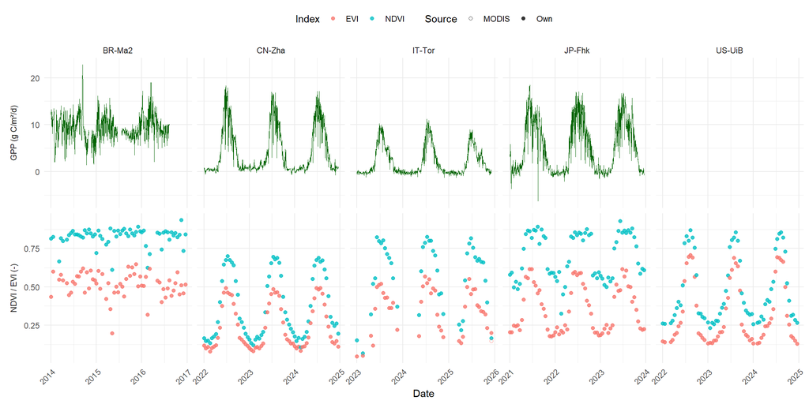

Daily GPP (top) and NDVI and EVI (bottom) for each tower over the MODIS period. Own values (filled) and MODIS products (open) overlap almost exactly.

```r
# Tägliche GPP aus den Block-4-Daten (mit VUT/CUT- und NT/DT-Ersatz)
gpp_daily <- all_hh |>
  mutate(date = as.Date(time)) |>
  summarise(GPP = mean(GPP) * 1.0378, .by = c(site, date)) |>
  rename(site_id = site)

rng <- vi |> summarise(start = min(date), end = max(date), .by = site_id)

gpp_plot <- gpp_daily |>
  inner_join(rng, by = "site_id") |>
  filter(date >= start, date <= end) |>
  mutate(panel = "GPP (g C/m²/d)")

vi_long <- vi |>
  pivot_longer(c(own_ndvi, own_evi, modis_ndvi, modis_evi),
               names_to = c("source", "index"), names_sep = "_") |>
  mutate(index  = toupper(index),
         source = if_else(source == "own", "Own", "MODIS"),
         panel  = "NDVI / EVI (-)")

ggplot() +
  geom_line(data = gpp_plot, aes(date, GPP), colour = "darkgreen", linewidth = 0.3) +
  geom_point(data = vi_long, aes(date, value, colour = index, shape = source),
             size = 1.6, alpha = 0.8) +
  facet_grid(panel ~ site_id, scales = "free", switch = "y") +
  scale_shape_manual(values = c(Own = 16, MODIS = 1)) +
  labs(x = "Date", y = NULL, colour = "Index", shape = "Source") +
  theme_minimal(base_size = 11) +
  theme(strip.placement = "outside", legend.position = "top",
        axis.text.x = element_text(angle = 45, hjust = 1))
```

Own and MODIS NDVI agree exactly (r = 1) at all towers; EVI agrees almost exactly (r ≥ 0.999). IT-Tor has the fewest valid dates (44).

At CN-Zha, IT-Tor and JP-Fhk, NDVI and EVI follow the seasonal course of GPP: both rise in spring, peak in summer and drop in autumn. At the tropical forest site BR-Ma2, in contrast, NDVI stays high (about 0.85) throughout the year, while GPP varies considerably. In such a dense, evergreen canopy NDVI is saturated, so changes in photosynthesis are not visible as changes in greenness. At US-UiB, no comparison is possible because GPP is missing for the MODIS period (2022–2024).

## 4. My question: soil C:N and light-use efficiency

**Question.** Is the topsoil C:N ratio related to ecosystem light-use efficiency (LUE) during the peak growing season across my five towers?

**Hypothesis.** Sites with a lower C:N ratio (more available nitrogen) have a higher LUE, because more nitrogen allows more photosynthetic capacity per leaf.

**Method.** Topsoil C:N is the ratio of soil organic carbon to total nitrogen from SoilGrids, thickness-weighted over 0–30 cm. LUE is the sum of daily GPP (g C m⁻² d⁻¹) divided by the sum of daily incoming shortwave radiation SW_IN_F (MJ m⁻² d⁻¹) over the three months with the highest mean GPP at each site. Leaf nitrogen per mass from PlantTraits is listed in the table but not used to answer the question (see below).

```r
# Topsoil 0–30 cm, gewichtet nach Schichtdicke
soil_top <- soil |>
  filter(top_cm < 30) |>
  mutate(w = bottom_cm - top_cm) |>
  summarise(value = weighted.mean(mean, w), .by = c(site_id, property)) |>
  pivot_wider(names_from = property, values_from = value) |>
  mutate(CN = soc / nitrogen)

# Tageswerte
daily <- all_hh |>
  mutate(date = as.Date(time)) |>
  summarise(GPP = mean(GPP) * 1.0378,       # g C m⁻² d⁻¹
            SW  = mean(SW_IN_F) * 0.0864,   # MJ m⁻² d⁻¹
            .by = c(site, date)) |>
  mutate(month = as.integer(format(date, "%m")))

# Die drei Monate mit der höchsten mittleren GPP
peak <- daily |>
  summarise(gpp_month = mean(GPP, na.rm = TRUE), .by = c(site, month)) |>
  group_by(site) |>
  slice_max(gpp_month, n = 3) |>
  ungroup() |>
  select(site, month)

# Lichtnutzungseffizienz
lue <- daily |>
  semi_join(peak, by = c("site", "month")) |>
  filter(!is.na(GPP), !is.na(SW)) |>
  summarise(LUE         = sum(GPP) / sum(SW),
            n_days      = n(),
            peak_months = paste(sort(unique(month)), collapse = ", "),
            .by = site) |>
  rename(site_id = site)

q <- lue |>
  left_join(soil_top |> select(site_id, soc, nitrogen, CN), by = "site_id") |>
  left_join(traits |> select(site_id, leaf_N_mass, leaf_N_mass_aoa), by = "site_id") |>
  arrange(CN)

q |>
  select(Site = site_id,
         `SOC (g kg⁻¹)` = soc, `N (g kg⁻¹)` = nitrogen, `C:N (–)` = CN,
         `Leaf N (mg g⁻¹)` = leaf_N_mass, `Leaf N AOA` = leaf_N_mass_aoa,
         `Peak months` = peak_months, `Days` = n_days,
         `LUE (g C MJ⁻¹)` = LUE) |>
  knitr::kable(digits = 2)
```

| Site | SOC (g kg⁻¹) | N (g kg⁻¹) | C:N (–) | Leaf N (mg g⁻¹) | Leaf N AOA | Peak months | Days | LUE (g C MJ⁻¹) |
| --- | --- | --- | --- | --- | --- | --- | --- | --- |
| CN-Zha | 7.15 | 1.12 | 6.40 | 24.51 | 0 | 6, 7, 8 | 1187 | 0.45 |
| US-UiB | 19.65 | 1.89 | 10.37 | 21.53 | 0 | 6, 7, 8 | 1266 | 0.61 |
| JP-Fhk | 39.42 | 3.04 | 12.95 | 20.89 | 0 | 6, 7, 8 | 1656 | 0.67 |
| BR-Ma2 | 18.13 | 1.36 | 13.33 | 19.88 | 0 | 1, 2, 3 | 1275 | 0.68 |
| IT-Tor | 82.77 | 5.42 | 15.26 | 20.65 | 0 | 6, 7, 8 | 1653 | 0.30 |

To account for the fact that dense canopies absorb more of the incoming light, LUE was also computed per absorbed light, using EVI as a simple proxy for the absorbed fraction: LUE (absorbed) = GPP / (SW_IN_F × EVI). Daily EVI was linearly interpolated between the 16-day MODIS dates. This is only possible for the MODIS period (last three tower years); US-UiB has no GPP in this period and is excluded (n = 4).

```r
# EVI täglich interpolieren (zwischen den 16-Tage-Terminen)
evi_d <- vi |>
  filter(!is.na(own_evi)) |>
  group_by(site_id) |>
  reframe({
    d <- seq(min(date), max(date), by = "day")
    e <- approx(date, own_evi, xout = d)$y
    tibble(date = d, evi = e)
  })

peak_s <- peak |> rename(site_id = site)

lue_evi <- daily |>
  rename(site_id = site) |>
  semi_join(peak_s, by = c("site_id", "month")) |>
  inner_join(evi_d, by = c("site_id", "date")) |>
  filter(!is.na(GPP), !is.na(SW), !is.na(evi)) |>
  summarise(LUE_same   = sum(GPP) / sum(SW),        # gleiche Tage, einfallendes Licht
            LUE_abs    = sum(GPP) / sum(SW * evi),  # pro absorbiertem Licht
            n_days_evi = n(),
            .by = site_id)

q <- q |> left_join(lue_evi, by = "site_id")

q |>
  select(Site = site_id, `C:N (-)` = CN,
         `LUE full record (g C/MJ)` = LUE,
         `LUE MODIS period (g C/MJ)` = LUE_same,
         `LUE absorbed (g C/MJ)` = LUE_abs,
         `Days (MODIS period)` = n_days_evi) |>
  knitr::kable(digits = 2)
```

| Site | C:N (-) | LUE full record (g C/MJ) | LUE MODIS period (g C/MJ) | LUE absorbed (g C/MJ) | Days (MODIS period) |
| --- | --- | --- | --- | --- | --- |
| CN-Zha | 6.40 | 0.45 | 0.52 | 1.15 | 276 |
| US-UiB | 10.37 | 0.61 | NA | NA | NA |
| JP-Fhk | 12.95 | 0.67 | 0.65 | 1.17 | 276 |
| BR-Ma2 | 13.33 | 0.68 | 0.69 | 1.30 | 271 |
| IT-Tor | 15.26 | 0.30 | 0.29 | 0.61 | 276 |

The PlantTraits area-of-applicability flag (`_aoa`) is 0 for all traits at all five towers. It is not yet clear whether 0 means inside or outside the area of applicability, so leaf N is not interpreted.

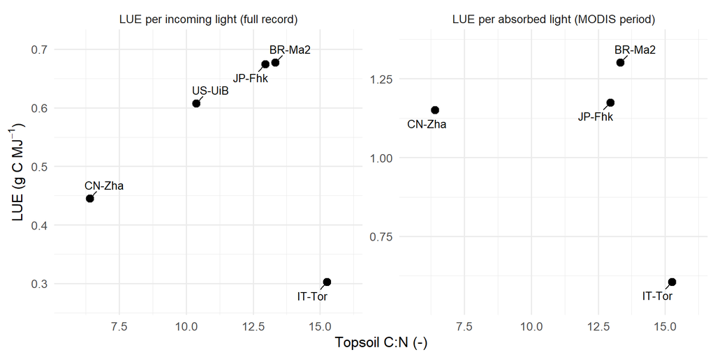

Peak-season light-use efficiency per incoming light (left, full record, n = 5) and per absorbed light (right, GPP / (SW_IN × EVI), MODIS period, n = 4) against topsoil C:N (SoilGrids, 0–30 cm).

```r
q |>
  select(site_id, CN,
         `LUE per incoming light (full record)` = LUE,
         `LUE per absorbed light (MODIS period)` = LUE_abs) |>
  pivot_longer(-c(site_id, CN), names_to = "measure") |>
    mutate(measure = factor(measure, levels = c("LUE per incoming light (full record)",
                                              "LUE per absorbed light (MODIS period)"))) |>
  filter(!is.na(value)) |>
  ggplot(aes(CN, value, label = site_id)) +
  geom_point(size = 3) +
  ggrepel::geom_text_repel(size = 3.5, box.padding = 0.5) +
  facet_wrap(~ measure, scales = "free_y") +
  scale_x_continuous(expand = expansion(mult = 0.15)) +
  scale_y_continuous(expand = expansion(mult = 0.15)) +
  labs(x = "Topsoil C:N (-)", y = expression("LUE (g C MJ"^-1*")")) +
  theme_minimal(base_size = 13)
```

Neither the table nor the figure supports the hypothesis: apart from IT-Tor, LUE per incoming light increases with C:N, from CN-Zha (C:N 6.4, LUE 0.45) to BR-Ma2 (C:N 13.3, LUE 0.68), which is the opposite of the expected direction. IT-Tor is a special case: at this alpine site, the short growing season and low temperatures limit photosynthesis as well as the microbial decomposition of organic matter, so it combines the highest C:N with the lowest LUE. Per absorbed light, the pattern becomes much weaker: CN-Zha moves up to the level of JP-Fhk (1.15 vs. 1.17 g C MJ⁻¹), which suggests that its low LUE per incoming light reflects a sparse canopy rather than inefficient leaves, although part of this jump may be a scale artefact (see Section 5). LUE per incoming light therefore partly measures canopy cover, which differs strongly between my sites. With only five towers (n = 5, and n = 4 per absorbed light) in very different climates, the comparison is descriptive, and any nitrogen signal is likely masked by climate, vegetation type, management (e.g. harvest at US-UiB) and partitioning method (DT at BR-Ma2). Moreover, 50–76 % of the NEE half hours are gap-filled using incoming radiation as a driver, so GPP and SW_IN are partly linked by construction. At CN-Zha, the low soil carbon, low C:N and high pH (8.4) suggest that the SoilGrids pixel represents the surrounding dry soils rather than the wetland. Testing the hypothesis properly would require more towers within a similar climate, for example the data of the whole class.class.

## 5. Scale

The flux footprint, the area the tower actually measures, is roughly 100 m to 1 km. The external datasets see very different areas:

```r
tibble::tribble(
  ~Dataset,       ~`Pixel / area`,             ~`Compared with footprint`, ~`What it means for my answer`,
  "SoilGrids",    "250 m",                     "similar",                  "Right scale for C:N, but a model prediction; at CN-Zha the pixel seems to show the dry surroundings (pH 8.4, low SOC), not the wetland.",
  "PlantTraits",  "1 km",                      "similar to larger",        "Mixes vegetation types around the tower; croplands and wetlands are poorly covered; AOA unclear.",
  "MODIS",        "250 m, 9 × 9 px (~2 × 2 km)", "larger",                 "The window includes land cover around the tower (other fields at US-UiB, desert/oasis at CN-Zha); greenness is not only the footprint.",
  "WorldClim",    "5′ (~9 km)",                "much larger",              "Regional climate only; in mountains (IT-Tor, JP-Fhk) one cell mixes very different elevations.",
  "iNaturalist",  "5 km radius",               "much larger",              "Records cluster along roads and towns; counts describe observers as much as species."
) |>
  knitr::kable()
```

| Dataset | Pixel / area | Compared with footprint | What it means for my answer |
| --- | --- | --- | --- |
| SoilGrids | 250 m | similar | Right scale for C:N, but a model prediction; at CN-Zha the pixel seems to show the dry surroundings (pH 8.4, low SOC), not the wetland. |
| PlantTraits | 1 km | similar to larger | Mixes vegetation types around the tower; croplands and wetlands are poorly covered; AOA unclear. |
| MODIS | 250 m, 9 × 9 px (~2 × 2 km) | larger | The window includes land cover around the tower (other fields at US-UiB, desert/oasis at CN-Zha); greenness is not only the footprint. |
| WorldClim | 5′ (~9 km) | much larger | Regional climate only; in mountains (IT-Tor, JP-Fhk) one cell mixes very different elevations. |
| iNaturalist | 5 km radius | much larger | Records cluster along roads and towns; counts describe observers as much as species. |

For my question, the most important scale issue is SoilGrids: the 250 m pixel matches the footprint in size, but at CN-Zha it probably does not represent the wetland soil. The C:N value used for this tower is therefore uncertain. Scale also matters for LUE per absorbed light: at CN-Zha, the 2 × 2 km MODIS window probably includes drier surroundings with lower EVI than the wetland footprint, which would make its LUE per absorbed light too high. LUE per incoming light, in contrast, uses only tower data and represents the footprint.

## Data and citation

**Time zone.** FLUXNET days are local standard time (no daylight saving). MODIS dates are the start dates of the 16-day composites. ERA5-Land was not used in this report.

**FLUXNET site data.** Each site’s data citation from the FLUXNET Shuttle snapshot:

- **BR-Ma2**: Alessandro Araujo, Celso von Randow, Antonio Manzi, Antonio Nobre, Gilberto Pastorello, Julie Andrews de França e Silva, Leila do Socorro Monteiro Leal, Marta Sá, Paulo Teixeira, Rita von Randow (2026), AmeriFlux FLUXNET-1F BR-Ma2 Manaus - ZF2 K34, Ver. v1.3_r1 (1999-2016), AmeriFlux AMP, (Dataset). https://doi.org/10.17190/AMF/3027671
- **US-UiB**: Carl J Bernacchi, Bethany Blakely, Caitlin Moore, Taylor Pederson (2026), AmeriFlux FLUXNET-1F US-UiB University of Illinois Miscanthus, Ver. v1.3_r1 (2008-2024), AmeriFlux AMP, (Dataset). https://doi.org/10.17190/AMF/3027337
- **JP-Fhk**: Hirata, R., Hirose, Y., Ide, R., Liang, N., Takahashi, Y., Yamao, Y. (2026). Fluxnet Archive Product from Fuji Hokuroku Flux Observation Site, 2006–2023, FLUXNET, https://hdl.handle.net/11676/5HO9DkOtLv80oPgti-3L_1gg
- **IT-Tor**: Galvagno, M., Cremonese, E., Morra di Cella, U. (2026). Fluxnet Archive Product from Torgnon, 2008–2025, FLUXNET, https://hdl.handle.net/11676/RwvbnA8B9w4xSHzjc5eV45CK
- **CN-Zha**: Liu, S., Che, T., Xu, Z. (2026). Fluxnet Archive Product from Zhangye wetland, 2012–2024, FLUXNET, https://hdl.handle.net/11676/tFBkzpRGg9Iwux3atrGwD_ur
- Pastorello, G. et al. (2020): The FLUXNET2015 dataset and the ONEFlux processing pipeline for eddy covariance data. *Scientific Data* 7, 225. https://doi.org/10.1038/s41597-020-0534-3

**External datasets** (access dates in Section 1):

- **SoilGrids 2.0:** Poggio, L. et al. (2021): SoilGrids 2.0: producing soil information for the globe with quantified spatial uncertainty. *SOIL* 7, 217–240. Data: ISRIC, soilgrids.org.
- **PlantTraits:** Lusk et al. (2026), *Nature Communications* 17, 1203. Data: planttraits.earth, https://doi.org/10.5281/zenodo.14646322.
- **WorldClim 2.1:** Fick, S. E. & Hijmans, R. J. (2017): WorldClim 2: new 1-km spatial resolution climate surfaces for global land areas. *International Journal of Climatology* 37, 4302–4315. Data: worldclim.org.
- **iNaturalist:** iNaturalist contributors (2026), research-grade observations accessed via api.inaturalist.org/v1 on 2026-11-20.
- **MODIS MOD13Q1:** Didan, K. (2021): MODIS/Terra Vegetation Indices 16-Day L3 Global 250m SIN Grid V061. NASA LP DAAC, https://doi.org/10.5067/MODIS/MOD13Q1.061. Accessed through the ORNL DAAC MODIS subset service, https://doi.org/10.3334/ORNLDAAC/1557.

**Acknowledgement.**

> FLUXNET data products were produced and harmonized by eddy covariance regional networks and data processing centers, including AmeriFlux, ChinaFlux, European Fluxes Database, ICOS, JapanFlux, KoFlux, OzFlux, SAEON, and TERN. These products also include a modified version of ERA5 hourly data provided by the Copernicus Climate Change Service.